# **Facial Emotion Detection**

### **Model Building**

- Import VGG16 upto the layer of your choice and add Fully Connected layers on top of it.

```python
# clearing backend
backend.clear_session()

# set random seed to ensure reproducible results
np.random.seed(93)
random.seed(93)
tf.random.set_seed(93)

# load saved model-ready data
fileID = open(os.path.join(path,'face_emotion_random_rgb_norm_1hot.pkl'),'br')
data = pickle.load(fileID)
fileID.close(); del fileID

# get the split of the data as their own variable & prepare the data for training the model
for key in list(data.keys()):
    exec(key+' = data[key]')
del data, key

# loading VGG16 model
input_shape = (48,48,3)
vgg16 = tf.keras.applications.VGG16(
    include_top=False, # removing the last FC prediction layer
    weights='imagenet',
    input_tensor=None,
    input_shape=input_shape,
    pooling='max',
    classes=1000,
    classifier_activation='softmax')

vgg16.summary()

vgg16.trainable = False
for layer in vgg16.layers:
    print(layer.name, layer.trainable)

# build the transfer learning model on top of VGG16
num_classes = 4
leaky_relu_slope = 0.1
dropout_rate = 0.5

x = tf.keras.layers.Flatten()(vgg16.get_layer('global_max_pooling2d').output)
x = tf.keras.layers.Dense(1024)(x)
x = tf.keras.layers.LeakyReLU(alpha=leaky_relu_slope)(x)
x = tf.keras.layers.Dense(256)(x)
x = tf.keras.layers.LeakyReLU(alpha=leaky_relu_slope)(x)
x = tf.keras.layers.Dropout(rate=dropout_rate)(x)
x = tf.keras.layers.BatchNormalization()(x)
outputs = tf.keras.layers.Dense(num_classes,activation='softmax')(x)
# initializing the model
model = tf.keras.Model(inputs=vgg16.input,outputs=outputs)

model.summary()
```

```
Model: "vgg16"
_________________________________________________________________
Layer (type)                 Output Shape              Param #
=================================================================
input_1 (InputLayer)         [(None, 48, 48, 3)]       0
_________________________________________________________________
block1_conv1 (Conv2D)        (None, 48, 48, 64)        1792
_________________________________________________________________
block1_conv2 (Conv2D)        (None, 48, 48, 64)        36928
_________________________________________________________________
block1_pool (MaxPooling2D)   (None, 24, 24, 64)        0
_________________________________________________________________
block2_conv1 (Conv2D)        (None, 24, 24, 128)       73856
_________________________________________________________________
block2_conv2 (Conv2D)        (None, 24, 24, 128)       147584
_________________________________________________________________
block2_pool (MaxPooling2D)   (None, 12, 12, 128)       0
_________________________________________________________________
block3_conv1 (Conv2D)        (None, 12, 12, 256)       295168
_________________________________________________________________
block3_conv2 (Conv2D)        (None, 12, 12, 256)       590080
_________________________________________________________________
block3_conv3 (Conv2D)        (None, 12, 12, 256)       590080
_________________________________________________________________
block3_pool (MaxPooling2D)   (None, 6, 6, 256)         0
_________________________________________________________________
block4_conv1 (Conv2D)        (None, 6, 6, 512)         1180160
_________________________________________________________________
block4_conv2 (Conv2D)        (None, 6, 6, 512)         2359808
_________________________________________________________________
block4_conv3 (Conv2D)        (None, 6, 6, 512)         2359808
_________________________________________________________________
block4_pool (MaxPooling2D)   (None, 3, 3, 512)         0
_________________________________________________________________
block5_conv1 (Conv2D)        (None, 3, 3, 512)         2359808
_________________________________________________________________
block5_conv2 (Conv2D)        (None, 3, 3, 512)         2359808
_________________________________________________________________
block5_conv3 (Conv2D)        (None, 3, 3, 512)         2359808
_________________________________________________________________
```

[output cut: 77 more lines]

```
_________________________________________________________________
dense_1 (Dense)              (None, 256)               262400
_________________________________________________________________
leaky_re_lu_1 (LeakyReLU)    (None, 256)               0
_________________________________________________________________
dropout (Dropout)            (None, 256)               0
_________________________________________________________________
batch_normalization (BatchNo (None, 256)               1024
_________________________________________________________________
dense_2 (Dense)              (None, 4)                 1028
=================================================================
Total params: 15,504,452
Trainable params: 789,252
Non-trainable params: 14,715,200
_________________________________________________________________
```

### **Compiling and Training the VGG16 Model**

```python
# compiling the model
learning_rate = 0.001
model.compile(optimizer = tf.keras.optimizers.Adamax(learning_rate=learning_rate),loss='categorical_crossentropy',metrics=['accuracy'])

# rename the model
model_vgg16_tl = model

# Fit the model
batch_size = 256
validation_split = 0.2
epoch = 20
history_model_vgg16 = model_vgg16_tl.fit(x=x_train,
                               y=y_train,
                               batch_size=batch_size,
                               epochs=epoch,
                               validation_split=validation_split,
                               verbose=1)

# saving model after training (retain model without taking the time to train again to get the model)
model_vgg16_tl.save(os.path.join(path,'model_vgg16_tl.h5'))
# save model history
fileID = open(os.path.join(path,'history_model_vgg16.pkl'),'bw')
pickle.dump({'history_model':history_model_vgg16.history},fileID)
fileID.close(); del fileID
```

### **Evaluating the VGG16 model**

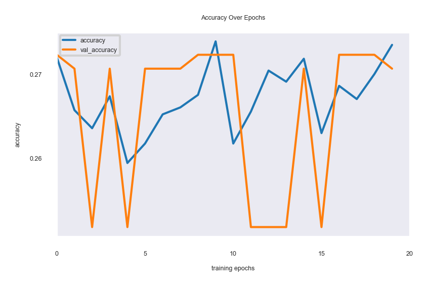

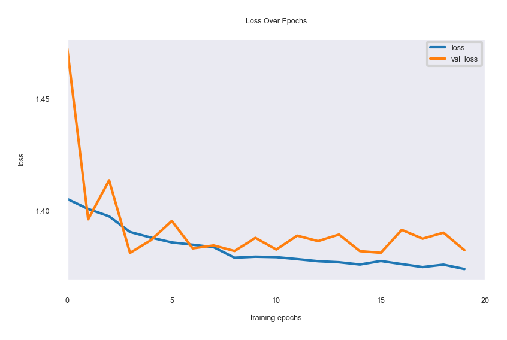

```
Evaluation loss 2.186305522918701
Evaluation accuracy: 0.421875
==== Classification report ====

               precision    recall  f1-score   support

           0       0.22      0.06      0.10        32
           1       0.33      0.66      0.44        32
           2       0.76      0.59      0.67        32
           3       0.39      0.38      0.38        32

    accuracy                           0.42       128
   macro avg       0.43      0.42      0.40       128
weighted avg       0.43      0.42      0.40       128

==== Confusion matrix ====

 [[ 2 18  3  9]
 [ 4 21  0  7]
 [ 2  8 19  3]
 [ 1 16  3 12]]
```

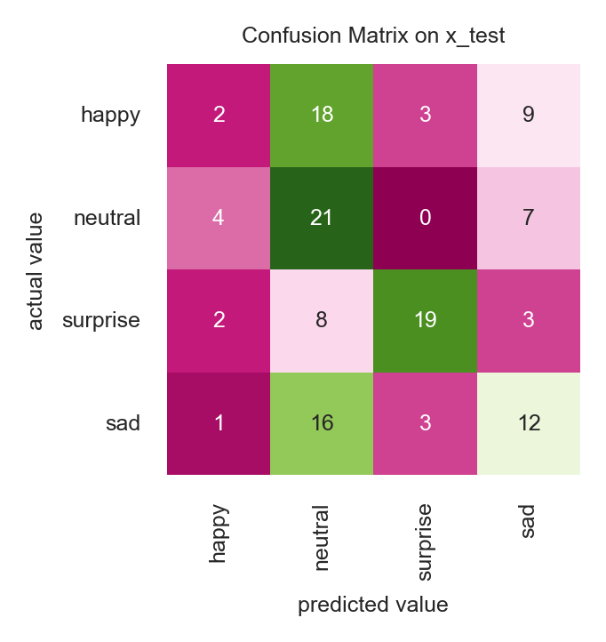

```python
# load saved model-ready data
fileID = open(os.path.join(path,'face_emotion_random_rgb_norm_1hot.pkl'),'br')
data = pickle.load(fileID)
fileID.close(); del fileID

# get the split of the data as their own variable & prepare the data for training the model
for key in list(data.keys()):
    exec(key+' = data[key]')
del data, key

# load model ======================================
model_vgg16_tl = tf.keras.models.load_model(os.path.join(path,'model_vgg16_tl.h5'))
# load history
fileID = open(os.path.join(path,'history_model_vgg16.pkl'),'br')
history_model_vgg16 = pickle.load(fileID)
fileID.close(); del fileID

# plot training accuracy
fig = plt.figure(dpi=300,figsize=(3,1.75))
try:
    for key in history_model_vgg16.history.keys():
        if 'accuracy' in key:
            plt.plot(history_model_vgg16.history[key],linewidth=1,label=key)
            plt.xlim([0,len(history_model_vgg16.history[key])])
except:
    for key in history_model_vgg16['history_model'].keys():
        if 'accuracy' in key:
            plt.plot(history_model_vgg16['history_model'][key],linewidth=1,label=key)
            plt.xlim([0,len(history_model_vgg16['history_model'][key])])
plt.ylabel('accuracy',fontsize=3)
plt.xlabel('training epochs',fontsize=3)
plt.xticks(fontsize=3)
plt.yticks(fontsize=3)#,ticks=np.arange(0.2,0.35,0.05),labels=np.round(np.arange(0.2,0.35,0.05),decimals=2))
plt.title('Accuracy Over Epochs',fontsize=3)
plt.legend(fontsize=3)
plt.show()

fig = plt.figure(dpi=300,figsize=(3,1.75))
try:
    for key in history_model_vgg16.history.keys():
        if 'loss' in key:
            plt.plot(history_model_vgg16.history[key],linewidth=1,label=key)
            plt.xlim([0,len(history_model_vgg16.history[key])])
except:
    for key in history_model_vgg16['history_model'].keys():
        if 'loss' in key:
            plt.plot(history_model_vgg16['history_model'][key],linewidth=1,label=key)
            plt.xlim([0,len(history_model_vgg16['history_model'][key])])
plt.ylabel('loss',fontsize=3)
plt.xlabel('training epochs',fontsize=3)
plt.xticks(fontsize=3)
plt.yticks(fontsize=3)
plt.title('Loss Over Epochs',fontsize=3)
plt.legend(fontsize=3)
plt.show()


# test set evaluation ================================================
score = model_vgg16_tl.evaluate(x_test,y_test,verbose=1)
score_names = model_vgg16_tl.metrics_names
print('Evaluation %s' %(score_names[0]), score[0])
print('Evaluation %s:' %(score_names[1]), score[1])

# make prediction
predict_model_vgg16_prob = model_vgg16_tl.predict(x_test)

# converting one-hot back in to class labelss
y_test_class = np.argmax(y_test,axis=1)
predict_model_vgg16_class = np.argmax(predict_model_vgg16_prob,axis=1) # predict (highest probability)

# classification report
print('==== Classification report ====\n\n',classification_report(y_test_class,predict_model_vgg16_class,zero_division=0))

# confusion matrix
print('==== Confusion matrix ====\n\n',confusion_matrix(y_test_class,predict_model_vgg16_class))

fig = plt.figure(dpi=300,figsize=(2,2))
sns.set_style('dark')
cm = confusion_matrix(y_test_class,predict_model_vgg16_class)
sns.heatmap(cm,annot=True,cmap='PiYG',fmt='g',cbar=False,xticklabels=list(key_class.keys()),yticklabels=list(key_class.keys()),annot_kws={"size":6})
plt.title('Confusion Matrix on x_test',fontsize=6)
plt.xlabel('predicted value',fontsize=6)
plt.ylabel('actual value',fontsize=6)
plt.xticks(fontsize=6)
plt.yticks(fontsize=6)
plt.show()
```

**Think About It:**

- What do you infer from the general trend in the training performance?

Poor performance, even after trying to tune the model. Further discussion on this in the section below.

- Is the training accuracy consistently improving?

The training accuracy is not improving overall during the training process, hovering about 27%.

- Is the validation accuracy also improving similarly?

The validation accuracy is also not improving as does the training accuracy, it also hovers around 27%. This would indicate that there is almost no learning over the training process. Further detailed discussion on this in the seciton below.

**Observations and Insights:**

**Note: You can even go back and build your own architecture on top of the VGG16 Transfer layer and see if you can improve the performance**

## **ResNet V2 Model**

```python
# clearing backend
backend.clear_session()

# set random seed to ensure reproducible results
np.random.seed(84)
random.seed(84)
tf.random.set_seed(84)

# load saved model-ready data
fileID = open(os.path.join(path,'face_emotion_random_rgb_norm_1hot.pkl'),'br')
data = pickle.load(fileID)
fileID.close(); del fileID

# get the split of the data as their own variable & prepare the data for training the model
for key in list(data.keys()):
    exec(key+' = data[key]')
del data, key

# x_test = x_test/255.0
# x_train = x_train/255.0
# x_validation = x_validation/255.0

# load the ResNet V2 model
input_shape = (48,48,3)
resnet152v2 = tf.keras.applications.ResNet152V2(
    include_top=False,
    weights='imagenet',
    input_tensor=None,
    input_shape=input_shape,
    pooling=None,
    classes=1000,
    classifier_activation='softmax')


resnet152v2.trainable = False

for layer in resnet152v2.layers:
    print(layer.name, layer.trainable)

resnet152v2.summary()
```

[output not shown]

[output cut: 1695 more lines]

```
conv5_block3_2_relu (Activation (None, 2, 2, 512)    0           conv5_block3_2_bn[0][0]
__________________________________________________________________________________________________
conv5_block3_3_conv (Conv2D)    (None, 2, 2, 2048)   1050624     conv5_block3_2_relu[0][0]
__________________________________________________________________________________________________
conv5_block3_out (Add)          (None, 2, 2, 2048)   0           conv5_block2_out[0][0]
                                                                 conv5_block3_3_conv[0][0]
__________________________________________________________________________________________________
post_bn (BatchNormalization)    (None, 2, 2, 2048)   8192        conv5_block3_out[0][0]
__________________________________________________________________________________________________
post_relu (Activation)          (None, 2, 2, 2048)   0           post_bn[0][0]
==================================================================================================
Total params: 58,331,648
Trainable params: 0
Non-trainable params: 58,331,648
__________________________________________________________________________________________________
```

### **Model Building**

- Import Resnet v2 upto the layer of your choice and add Fully Connected layers on top of it.

```python
# build the transfer learning model on top of ResNet V2
num_classes = 4
leaky_relu_slope = 0.1
dropout_rate = 0.5

x = tf.keras.layers.Flatten()(resnet152v2.get_layer('post_relu').output)
x = tf.keras.layers.Dense(1024)(x)
x = tf.keras.layers.LeakyReLU(alpha=leaky_relu_slope)(x)
x = tf.keras.layers.Dense(256)(x)
x = tf.keras.layers.LeakyReLU(alpha=leaky_relu_slope)(x)
x = tf.keras.layers.Dropout(rate=dropout_rate)(x)
x = tf.keras.layers.BatchNormalization()(x)
outputs = tf.keras.layers.Dense(num_classes,activation='softmax')(x)
# initializing the model
model = tf.keras.Model(inputs=resnet152v2.input, outputs=outputs)

model.summary()
```

```
Model: "functional_1"
__________________________________________________________________________________________________
Layer (type)                    Output Shape         Param #     Connected to
==================================================================================================
input_1 (InputLayer)            [(None, 48, 48, 3)]  0
__________________________________________________________________________________________________
conv1_pad (ZeroPadding2D)       (None, 54, 54, 3)    0           input_1[0][0]
__________________________________________________________________________________________________
conv1_conv (Conv2D)             (None, 24, 24, 64)   9472        conv1_pad[0][0]
__________________________________________________________________________________________________
pool1_pad (ZeroPadding2D)       (None, 26, 26, 64)   0           conv1_conv[0][0]
__________________________________________________________________________________________________
pool1_pool (MaxPooling2D)       (None, 12, 12, 64)   0           pool1_pad[0][0]
__________________________________________________________________________________________________
conv2_block1_preact_bn (BatchNo (None, 12, 12, 64)   256         pool1_pool[0][0]
__________________________________________________________________________________________________
conv2_block1_preact_relu (Activ (None, 12, 12, 64)   0           conv2_block1_preact_bn[0][0]
__________________________________________________________________________________________________
conv2_block1_1_conv (Conv2D)    (None, 12, 12, 64)   4096        conv2_block1_preact_relu[0][0]
__________________________________________________________________________________________________
conv2_block1_1_bn (BatchNormali (None, 12, 12, 64)   256         conv2_block1_1_conv[0][0]
__________________________________________________________________________________________________
conv2_block1_1_relu (Activation (None, 12, 12, 64)   0           conv2_block1_1_bn[0][0]
__________________________________________________________________________________________________
conv2_block1_2_pad (ZeroPadding (None, 14, 14, 64)   0           conv2_block1_1_relu[0][0]
__________________________________________________________________________________________________
conv2_block1_2_conv (Conv2D)    (None, 12, 12, 64)   36864       conv2_block1_2_pad[0][0]
__________________________________________________________________________________________________
conv2_block1_2_bn (BatchNormali (None, 12, 12, 64)   256         conv2_block1_2_conv[0][0]
__________________________________________________________________________________________________
conv2_block1_2_relu (Activation (None, 12, 12, 64)   0           conv2_block1_2_bn[0][0]
__________________________________________________________________________________________________
conv2_block1_0_conv (Conv2D)    (None, 12, 12, 256)  16640       conv2_block1_preact_relu[0][0]
__________________________________________________________________________________________________
conv2_block1_3_conv (Conv2D)    (None, 12, 12, 256)  16640       conv2_block1_2_relu[0][0]
__________________________________________________________________________________________________
conv2_block1_out (Add)          (None, 12, 12, 256)  0           conv2_block1_0_conv[0][0]
                                                                 conv2_block1_3_conv[0][0]
__________________________________________________________________________________________________
conv2_block2_preact_bn (BatchNo (None, 12, 12, 256)  1024        conv2_block1_out[0][0]
```

[output cut: 1147 more lines]

```
__________________________________________________________________________________________________
dense_1 (Dense)                 (None, 256)          262400      leaky_re_lu[0][0]
__________________________________________________________________________________________________
leaky_re_lu_1 (LeakyReLU)       (None, 256)          0           dense_1[0][0]
__________________________________________________________________________________________________
dropout (Dropout)               (None, 256)          0           leaky_re_lu_1[0][0]
__________________________________________________________________________________________________
batch_normalization (BatchNorma (None, 256)          1024        dropout[0][0]
__________________________________________________________________________________________________
dense_2 (Dense)                 (None, 4)            1028        batch_normalization[0][0]
==================================================================================================
Total params: 66,985,732
Trainable params: 8,653,572
Non-trainable params: 58,332,160
__________________________________________________________________________________________________
```

### **Compiling and Training the Model**

```python
# compiling the model
learning_rate = 0.001
model.compile(optimizer = tf.keras.optimizers.Adamax(learning_rate=learning_rate),loss = 'categorical_crossentropy',metrics = ['accuracy'])

# rename the model
model_resnet152v2_tl = model

# fit the model
batch_size = 256
validation_split = 0.2
epoch = 20
history_model_resnet152v2 = model_resnet152v2_tl.fit(x=x_train,
                               y=y_train,
                               batch_size=batch_size,
                               epochs=epoch,
                               validation_split=validation_split,
                               verbose=1)

# saving model after training (retain model without taking the time to train again to get the model)
model_resnet152v2_tl.save(os.path.join(path,'model_resnet152v2_tl.h5'))
# save model history
fileID = open(os.path.join(path,'model_resnet152v2_hist.pkl'),'bw')
pickle.dump({'history_model':history_model_resnet152v2.history},fileID)
fileID.close(); del fileID
```